# Client-Alessandro Marvelo

client consultation

Flynn Entwistle, Gisella Sutanto, Yoon Hee Cha

18/04/2024

# 1 Executive Summary

The client is currently formulating her ethics application for an upcoming research—to evaluate the effects of a patient decision aid for people whose currently taking opioids to cure backpain. The experiment is going to be a double blinded randomized control trial. They wish for us to calculate the sample size needed for conducting the trial. Based on the results of power test we can approximate the number of samples needed to accomodate her request.

# 2 Introduction

The client is working on her ethics application for an upcoming research on the effects of decision aid for patients that considered taking opioids to cure backpain.

## 2.1 Background of the project

The planned research is a randomised controlled trial (RCT) methodology, which meant a calculation on the amount of control and intervention group is needed. The primary outcome—which will be used for the power analysis— of the client’s research is to see whether treatment aid would influence the participant’s decision to take Opioids or not. Sample size will be taken from patients who both had Opiods and not.

**Aims demonstrated in this report**

- The Power statistic calculation using **pwr.t.test** from the package **pwr**
- A theoretical visualisation of the power analysis
- A plan for the statistical calculation/methodology, modeled based off the reference paper.
- Data Analysis Plan

# 3 Power Analysis

Client wishes to mirror statistical analysis methodology from a previous statistical study. two different approaches on aquiring sample number will be given, one being based on the paper’s method and the other being based of client’s inquiry.

## 3.1 Sample Number Calculation Based on Paper Methodology

Power analysis on paired two-sample t-test on primary outcome Treatment Intention: 90% power. alpha = 0.05. How many samples is sufficient to detect a 12% difference betweeen individuals intending to undergo surgery from the control and intervention group means?

The referenced research paper took the sample size by dividing the likert scale dichotomously, the sample size calculation follows the paper’s methodology of ignoring the range given by it’s likert scale of 0-15.

with pwr.t.test the below numbers are given

```r
suppressPackageStartupMessages(library(tidyverse))
suppressPackageStartupMessages(library(pwr))
suppressPackageStartupMessages(library(ggplot2))
```

In the case of proportions , Cohen’s d can be calculated using the formula:

$$d = \frac{{|\Phi^{-1}(p_1) -
\Phi^{-1}(p_2)|}}{{\sqrt{2}}}$$

where $\Phi^{-1}(p)$ is the inverse cumulative distribution function of the standard normal distribution, and $p_1$ and $p_2$ are the proportions in the two groups.

```r
# effect size calculation

p1 <- 0.70  # Proportion in group 1 (decision aid)
p2 <- 0.82  # Proportion in group 2 (control)


# Calculate the effect size (Cohen's d)
effect_size <- abs(qnorm(p1) - qnorm(p2)) / sqrt(2)

#Print the result
#In this case, the effect size is 0.276.

n_total <- 396  # Total sample size
alpha <- 0.05  # Significance level
power <- 0.9  # Desired power


pwr.t.test(d = 0.283, sig.level = alpha, power = 0.9, type = "two.sample")
```

```
##
##      Two-sample t test power calculation
##
##               n = 263.3576
##               d = 0.283
##       sig.level = 0.05
##           power = 0.9
##     alternative = two.sided
##
## NOTE: n is number in *each* group
```

Based on the consulting session, client wishes to do a sample size calculation which does not summarise the scale into two category (intention is measured based on scale).

## 3.2 Sample Size Calculation with a likert scale

By considering the likert scale, a different approach will be needed. Pwr.t.test assumes the samples collected are continous however, knowing that the client intended to use discrete point scales, another power test will be performed.

Through simulating a value, an assumption on the sample size can be collected.

### 3.2.1 Simulating power across Likert scale range

Below is the power simulated for paired t-tests across Likert scale range. which will show how many sample is needed to provide a 90% for any given scale

```r
# helper function for calculating SD
  # as scale increases, SD should naturally increase as well (makes sense for survey data).
  # this function increases SD proportionately to the % increase in scale by adding an extra point.
    # approximates the SD of the reference paper pretty well, so works for our purposes.
get_sd <- function(scale) {
  if (max(scale) == 2) {
    return (1)
  }
  return ( get_sd(max(scale - 1)) + (1 / max(scale)) )
}

set.seed(123)

# Calculates power as the percentage of B t-tests which correctly reject H0.
calculate_paired_t_test_power <- function(scale, alpha, mean_difference_percentage, n1, n2, B) {

  # Counter for every time null hypothesis is correctly rejected.
  correctly_rejected_H0s <- 0

  # mean on scale
  mean_scale = mean(scale)
  sd = get_sd(scale)

  # Mean of 2 groups (to generate sampling probability)
  mu_1 = mean_scale*(1 - (mean_difference_percentage/2))
  mu_2 = mean_scale*(1 + (mean_difference_percentage/2))

  # Generate sampling weights corresponding to a normal distribution.
  weights_group1 <- dnorm(scale, mean = mu_1, sd = sd)
  weights_group1 <- weights_group1 / sum(weights_group1)  # normalize weights to sum to 1

  weights_group2 <- dnorm(scale, mean = mu_2, sd = sd)
  weights_group2 <- weights_group2 / sum(weights_group2) # same as above

  # Perform simulations
  for (i in 1:B) {

    # Sample integers in specified scale using the calculated weights for each group
    samples_group1 <- sample(scale, size = n1, replace = TRUE, prob = weights_group1)
    samples_group2 <- sample(scale, size = n2, replace = TRUE, prob = weights_group2)

    # paired t-test on generated data.
    t_test <- t.test(samples_group1, samples_group2,
                     alternative = "two.sided",
                     mu = 0,
                     paired = FALSE,
                     var.equal = TRUE,
                     conf.level = 1-alpha)

    # Check if the result is significant
    if (t_test$p.value < alpha) {
      correctly_rejected_H0s <- correctly_rejected_H0s + 1
    }
  }

  # Calculate power
  power <- correctly_rejected_H0s / B
  return (power)
}

B = 2000

alpha = 0.05

mean_difference_percentage = 0.12

n1 = 200

n2 = 200

power_vec_n200 = vector()

for (i in 2:20) {

power_vec_n200[i-1] = calculate_paired_t_test_power(1:i, alpha, mean_difference_percentage, n1, n2, B)

}

n1 = 250

n2 = n1

power_vec_n250 = vector()

for (i in 2:20) {

power_vec_n250[i-1] = calculate_paired_t_test_power(1:i, alpha, mean_difference_percentage, n1, n2, B)

}

n1 = 300

n2 = n1

power_vec_n300 = vector()

for (i in 2:20) {

power_vec_n300[i-1] = calculate_paired_t_test_power(1:i, alpha, mean_difference_percentage, n1, n2, B)

}
```

**Plotting Power by Scale for each sample size.**

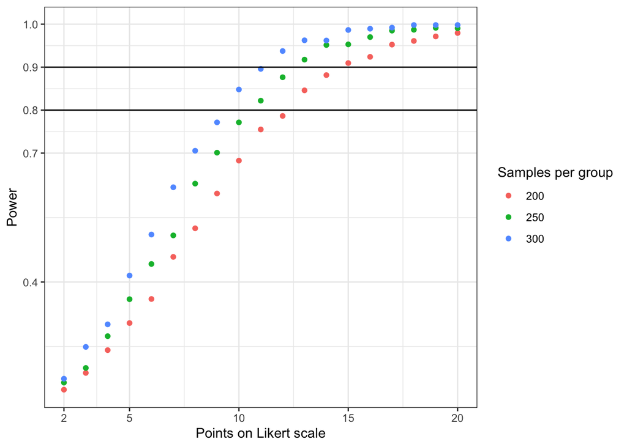

```r
scale_power_n = data.frame(power_vec_n200, power_vec_n250, power_vec_n300, 2:20)

long_scale_pwr_n = scale_power_n |>
  pivot_longer(
    cols = starts_with("power_vec_n"),
    names_to = ("Samples per group"),
    names_prefix = "power_vec_n",
    values_to = "Power"
      ) |> mutate(`Samples per group` = factor(`Samples per group`))

colnames(long_scale_pwr_n) = c("Points on Likert scale", "Samples per group", "Power")



long_scale_pwr_n |> ggplot() +
  geom_point(aes(x=`Points on Likert scale`, y=`Power`, color = `Samples per group`)) +
  geom_hline(yintercept=0.8) +
  geom_hline(yintercept=0.9) +
  scale_y_continuous(breaks = sort(c(seq(round(min(long_scale_pwr_n$Power), 1), round(max(long_scale_pwr_n$Power), 1), length.out=4), 0.8, 0.9))) +
  scale_x_continuous(breaks = c(2, 5, 10, 15, 20)) +
  theme_bw()
```

**The Plot Indiciates**

- 200 samples per group is enough to do a 15 point on a likert scale

## 3.3 Control and Intervention amount

- We recommend an equal divide on the amount of intervention and control patient.
- an added 20% from the given amount to consider unresponsive samples

# 4 Data analysis plan

### 4.0.1 **We encourage the client to :**

- Generate summary statistics and view the distribution of observations for participant demographics, symptoms, and outcome responses.
- T-tests for comparisons on numerical outcomes, Chi-sq for categorical outcomes: Two-sample t-test (based on the likert scale of 0-15) for control and intervention comparisons. (In reference to the paper, a secondary outcome was made by binning treatment intention into >= and < 50%).
- Perform logistic regression on effect of intervention on intention to try / not try Opioids. Sensitivity analysis on time it took participants to complete the survey.

### 4.0.2 **Data analysis plan**

All analyses will be blinded to group status and will be by intention-to-treat. Statistical significance will be defined as P<0.05 based on a two-sided test. The primary outcome will be analysed using a Student two sample T-test. Analysis adjusted for baseline scores and other demographic and clinical characteristics will also be performed using analysis of covariance models with the change from baseline as the dependent variable. A secondary analysis including data from all follow-ups and will be conducted using repeated measures with a (0-15) Likert scale. The remaining outcome measures will also be regarded as secondary and analysed separately with a logistic regression for dichotomous measures and linear regression analysis for continuous outcome.